# TESTING SA2

Sinocruz, A

2025-12-12

```r
# Load required libraries
library(tidyverse)
library(car)
library(multcomp)
library(emmeans)
library(rstatix)
library(knitr)
library(kableExtra)
```

```r
library(ggplot2)

# If you have CSV, change the path here please. Thank you!
data <- read.csv("C:/Users/Arvie Sinocruz/Downloads/Alzheimers Mice Data.csv")


data <- data %>%
  mutate(
    AD_Status = factor(AD_Status, labels = c("Transgenic", "Wild")),
    Treatment = factor(Treatment, labels = c("Drug1", "Drug2", "Drug3", "Drug4"))
  )

# View first few rows
head(data) %>% kable(caption = "First 6 Rows of Alzheimer Mice Dataset")
```

First 6 Rows of Alzheimer Mice Dataset

| AD_Status | Treatment | Training | Memory |
| --- | --- | --- | --- |
| Transgenic | Drug1 | 12 | 10 |
| Transgenic | Drug1 | 15 | 12 |
| Transgenic | Drug1 | 13 | 13 |
| Transgenic | Drug1 | 12 | 10 |
| Transgenic | Drug1 | 14 | 13 |
| Transgenic | Drug2 | 15 | 13 |

## Assumptions

Prior to conducting the ANOVA, the underlying assumptions will be evaluated:

**Assumption 1:** You have one dependent variable that is measured at the continuous level.

**Assumption 2**: You have one independent variable that consists of three or more categorical, independent groups.

**Assumption 3:** You should have independence of observations, which means that there is no relationship between the observations in each group of the independent variable or among the groups themselves.

**Assumption 4:** There should be no significant outliers in the three or more groups of your independent variable in terms of the dependent variable.

**Assumption 5:** Your dependent variable should be approximately normally distributed for each group of the independent variable.

**Assumption 6:** You have homogeneity of variances (i.e., the variance of the dependent variable is equal in each group of your independent variable).

## Data Description

This study uses an experimental design involving mice to evaluate drug efficacy in models of Alzheimer’s disease (AD). The experimental setup incorporates two main factors:

**AD Status (Genotype):** Half of the mice are transgenic, meaning they have been genetically modified to develop AD pathology. The remaining half are wild-type, serving as non-modified controls presumed to be free of AD. **Treatment:** Mice are systematically assigned to one of four distinct drug administration conditions.

Cognitive performance is measured using a maze task. The number of errors recorded serves as the dependent variable across two distinct time points:

**Training Day Errors:** Measures initial acquisition and learning performance. **Memory Day Errors:** Measures retention and long-term memory performance.

## **Null and Alternative Hypotheses**

**For Training Day errors:**

H₀: The population means for Training Day Errors are equal across all levels of AD Status, Treatment, and there is no interaction between the two factors.

H₁: There is a significant difference in the mean Training Day Errors due to the main effect of AD Status, the main effect of Treatment, or their interaction.

**For Memory Day errors:**

H₀: The population means for Memory Day Errors are equal across all levels of AD Status, Treatment, and there is no interaction between the two factors.

H₁: There is a significant difference in the mean Memory Day Errors due to the main effect of AD Status, the main effect of Treatment, or their interaction.

# Descriptive Statistics

```r
desc_table <- data %>%
  group_by(AD_Status, Treatment) %>%
  summarise(
    Training_Mean = mean(Training),
    Training_SD   = sd(Training),
    Memory_Mean   = mean(Memory),
    Memory_SD     = sd(Memory),
    .groups = "drop"
  )

desc_table %>%
  kable(caption = "Means and Standard Deviations by AD Status and Treatment", digits = 2, "html") %>%
  kable_styling(full_width = F, bootstrap_options = c("striped", "hover", "condensed")) %>%
  row_spec(0, bold = TRUE, color = "white", background = "#4B8BBE") %>%
  column_spec(1:2, bold = TRUE) %>%
  column_spec(3:6, background = "#E6F0FA")
```

Means and Standard Deviations by AD Status and Treatment

| AD_Status | Treatment | Training_Mean | Training_SD | Memory_Mean | Memory_SD |
| --- | --- | --- | --- | --- | --- |
| Transgenic | Drug1 | 13.2 | 1.30 | 11.6 | 1.52 |
| Transgenic | Drug2 | 15.8 | 1.30 | 13.2 | 1.48 |
| Transgenic | Drug3 | 15.2 | 1.92 | 12.4 | 2.07 |
| Transgenic | Drug4 | 13.6 | 1.14 | 11.2 | 1.30 |
| Wild | Drug1 | 15.4 | 1.82 | 8.6 | 0.89 |
| Wild | Drug2 | 15.8 | 1.79 | 7.6 | 1.95 |
| Wild | Drug3 | 15.2 | 1.92 | 8.2 | 0.84 |
| Wild | Drug4 | 13.6 | 1.14 | 6.6 | 2.07 |

# Checking the ANOVA Assumptions

**Assumption 1:** The dependent variables, Training Errors and Memory Errors, represent the count of mistakes made in the maze. As count data, they are treated as ratio-level (continuous) data, satisfying the requirement for the ANOVA test.

*Remark:* Both variables are continuous count data, meeting this assumption.

**Assumption 2:** The independent variables (AD Status and Treatment) are categorical.

*Remark:* AD Status has 2 levels (Transgenic, Wild) and Treatment has 4 levels (Drug1–Drug4).

*Assumption 3:* Independence of observations.

*Remark:* The experimental design is a between-subjects design. Each mouse was assigned exclusively to one of the eight unique *AD_Status x Treatment combinations*. Therefore, the measurements are independent, as the performance of one mouse does not influence the performance of any other mouse.

*Assumption 4:* No significant outliers.

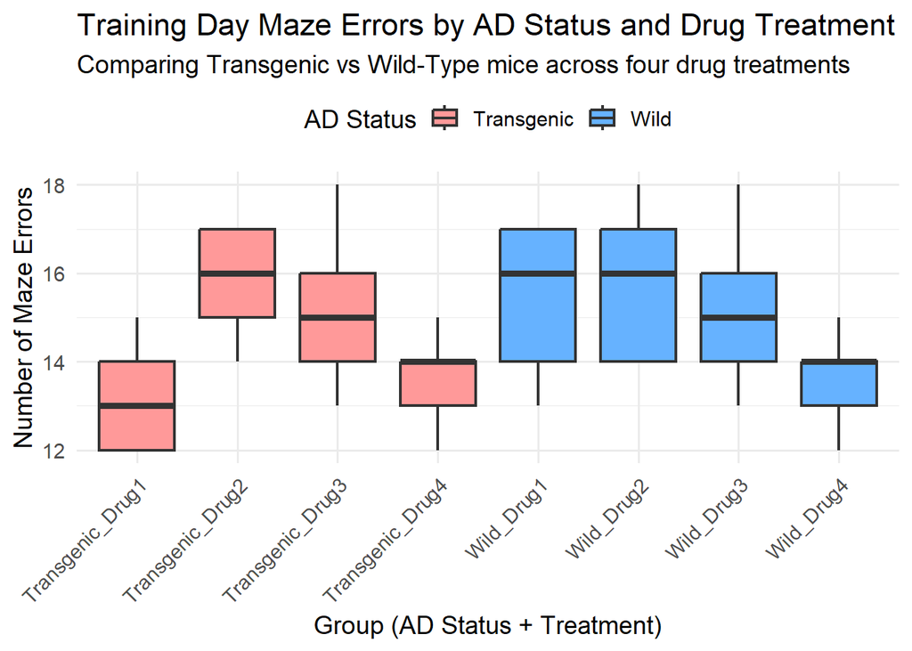

```r
# Check for outliers visually

# Training Day Boxplot
data %>%
  mutate(Group = paste0(AD_Status, "_", Treatment)) %>%
  ggplot(aes(x = Group, y = Training, fill = AD_Status)) +
  geom_boxplot(outlier.colour = "red", outlier.shape = 8, lwd = 0.8) +
  scale_fill_manual(values = c("#FF9999", "#66B2FF")) +
    labs(
    title = "Training Day Maze Errors by AD Status and Drug Treatment",
    subtitle = "Comparing Transgenic vs Wild-Type mice across four drug treatments",
    x = "Group (AD Status + Treatment)",
    y = "Number of Maze Errors",
    fill = "AD Status"
  ) +
  theme_minimal(base_size = 14) +
  theme(legend.position = "top",
        axis.text.x = element_text(angle = 45, hjust = 1))
```

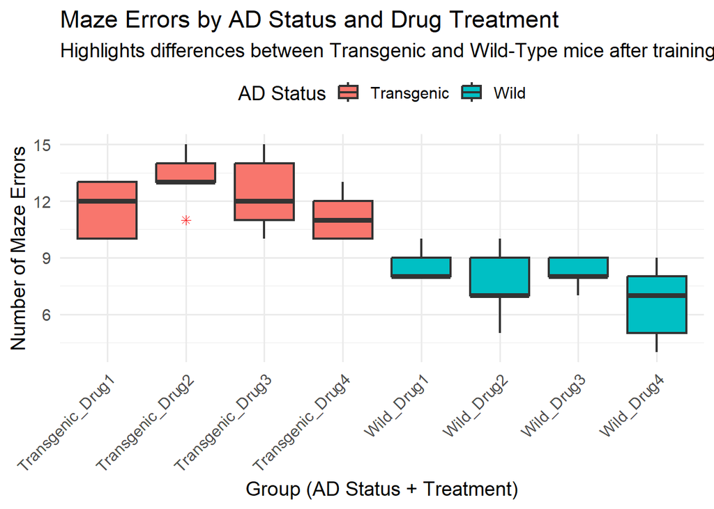

```r
# Memory Day Boxplot
data %>%
  mutate(Group = paste0(AD_Status, "_", Treatment)) %>%
  ggplot(aes(x = Group, y = Memory, fill = AD_Status)) +
  geom_boxplot(outlier.colour = "red", outlier.shape = 8, lwd = 0.8) +
  labs(
    title = "Maze Errors by AD Status and Drug Treatment",
    subtitle = "Highlights differences between Transgenic and Wild-Type mice after training",
    x = "Group (AD Status + Treatment)",
    y = "Number of Maze Errors",
    fill = "AD Status"
  ) +
  theme_minimal(base_size = 14) +
  theme(legend.position = "top",
        axis.text.x = element_text(angle = 45, hjust = 1))
```

**Assumption 5:** Normality of residuals.

```r
# Normality of residuals
training_aov <- aov(Training ~ AD_Status * Treatment, data = data)
memory_aov   <- aov(Memory   ~ AD_Status * Treatment, data = data)

# Normality
shapiro_training <- shapiro.test(residuals(training_aov))
shapiro_memory   <- shapiro.test(residuals(memory_aov))

shapiro_training
```

```
##
##  Shapiro-Wilk normality test
##
## data:  residuals(training_aov)
## W = 0.96357, p-value = 0.2214
```

```r
shapiro_memory
```

```
##
##  Shapiro-Wilk normality test
##
## data:  residuals(memory_aov)
## W = 0.96671, p-value = 0.2817
```

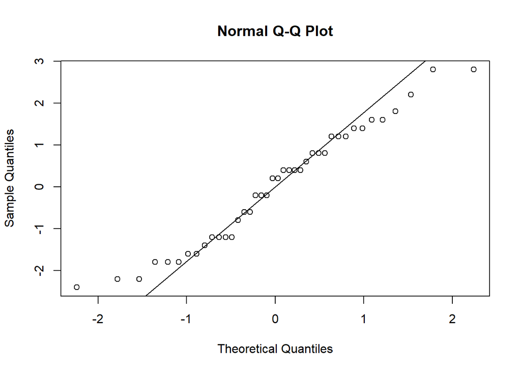

```r
# Q-Q Plots
qqnorm(residuals(training_aov)); qqline(residuals(training_aov))
```

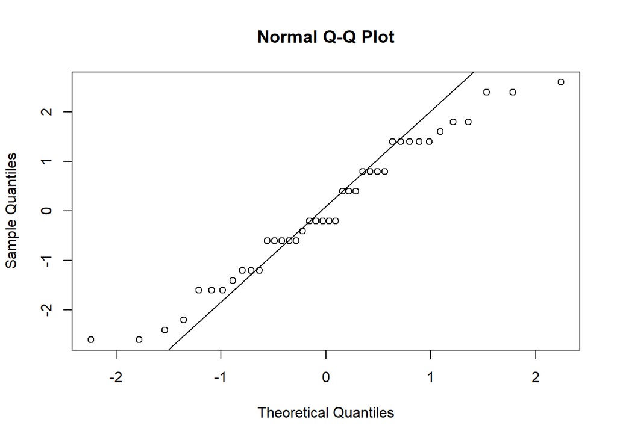

```r
qqnorm(residuals(memory_aov)); qqline(residuals(memory_aov))
```

*Remark:* Since both statistical tests and visual inspections indicate that the residuals are approximately normally distributed, **Assumption 5 (normality of residuals) is met**. This supports the validity of the ANOVA results, as the F-test relies on normally distributed errors within each group.

**Assumption 6:** Homogeneity of variances

```r
leveneTest(Training ~ AD_Status * Treatment, data = data)
```

|  | Df | F value | Pr(>F) |
| --- | --- | --- | --- |
| group | 7 | 0.4346076 | 0.8730506 |
|  | 32 | NA | NA |

```r
leveneTest(Memory   ~ AD_Status * Treatment, data = data)
```

|  | Df | F value | Pr(>F) |
| --- | --- | --- | --- |
| group | 7 | 0.8274583 | 0.57222 |
|  | 32 | NA | NA |

*Remark:* Since Levene’s Test results are non-significant, **Assumption 6 (homogeneity of variances) is satisfied**. This means that the ANOVA assumption of equal group variances holds, strengthening the reliability of the F-statistics and the post-hoc comparisons.

# Two-Way ANOVA

```r
# Training Day
training_anova_tbl <- tidy(training_aov) %>%
  mutate(Effect_Size = (sumsq / sum(sumsq)) * 100) # Partial eta squared approximation

training_anova_tbl %>%
  kable(caption = "Two-Way ANOVA for Training Day Errors", digits = 3, "html") %>%
  kable_styling(full_width = F, bootstrap_options = c("striped", "hover")) %>%
  row_spec(0, bold = TRUE, background = "#4B8BBE", color = "white") %>%
  column_spec(1:2, bold = TRUE)
```

Two-Way ANOVA for Training Day Errors

| term | df | sumsq | meansq | statistic | p.value | Effect_Size |
| --- | --- | --- | --- | --- | --- | --- |
| AD_Status | 1 | 3.025 | 3.025 | 1.216 | 0.278 | 2.521 |
| Treatment | 3 | 28.275 | 9.425 | 3.789 | 0.020 | 23.567 |
| AD_Status:Treatment | 3 | 9.075 | 3.025 | 1.216 | 0.320 | 7.564 |
| Residuals | 32 | 79.600 | 2.488 | NA | NA | 66.347 |

```r
# Memory Day
memory_anova_tbl <- tidy(memory_aov) %>%
  mutate(Effect_Size = (sumsq / sum(sumsq)) * 100)

memory_anova_tbl %>%
  kable(caption = "Two-Way ANOVA for Memory Day Errors", digits = 3, "html") %>%
  kable_styling(full_width = F, bootstrap_options = c("striped", "hover")) %>%
  row_spec(0, bold = TRUE, background = "#99CC66", color = "white") %>%
  column_spec(1:2, bold = TRUE)
```

Two-Way ANOVA for Memory Day Errors

| term | df | sumsq | meansq | statistic | p.value | Effect_Size |
| --- | --- | --- | --- | --- | --- | --- |
| AD_Status | 1 | 189.225 | 189.225 | 75.313 | 0.000 | 64.632 |
| Treatment | 3 | 14.475 | 4.825 | 1.920 | 0.146 | 4.944 |
| AD_Status:Treatment | 3 | 8.675 | 2.892 | 1.151 | 0.344 | 2.963 |
| Residuals | 32 | 80.400 | 2.512 | NA | NA | 27.461 |

*Remark:* The ANOVA results collectively suggest that drug treatment primarily affects learning performance during the training phase, but its effect does not differ between genotypes. In contrast, genotype is the dominant factor affecting memory retention, with transgenic mice consistently performing worse than wild-type mice, regardless of treatment. Interaction effects were non-significant in both analyses, indicating no evidence that drug efficacy depends on AD status. Effect size estimates further highlight the relative contributions of each factor, confirming that genotype plays a critical role in memory performance, whereas treatment has a more modest impact on learning.

# Post-Hoc Comparisions

```r
library(emmeans)

# Training Day: Treatment only
training_tukey_treatment <- emmeans(training_aov, pairwise ~ Treatment, adjust = "tukey")
```

```
## NOTE: Results may be misleading due to involvement in interactions
```

```r
training_tukey_treatment$contrasts %>%
  summary(infer = TRUE) %>%
  kable(caption = "Tukey Pairwise Comparisons for Training Day Errors by Treatment", digits = 3, "html") %>%
  kable_styling(full_width = F, bootstrap_options = c("striped", "hover")) %>%
  row_spec(0, bold = TRUE, background = "#4B8BBE", color = "white")
```

Tukey Pairwise Comparisons for Training Day Errors by Treatment

| contrast | estimate | SE | df | lower.CL | upper.CL | t.ratio | p.value |
| --- | --- | --- | --- | --- | --- | --- | --- |
| Drug1 - Drug2 | -1.5 | 0.705 | 32 | -3.411 | 0.411 | -2.127 | 0.166 |
| Drug1 - Drug3 | -0.9 | 0.705 | 32 | -2.811 | 1.011 | -1.276 | 0.584 |
| Drug1 - Drug4 | 0.7 | 0.705 | 32 | -1.211 | 2.611 | 0.992 | 0.755 |
| Drug2 - Drug3 | 0.6 | 0.705 | 32 | -1.311 | 2.511 | 0.851 | 0.830 |
| Drug2 - Drug4 | 2.2 | 0.705 | 32 | 0.289 | 4.111 | 3.119 | 0.019 |
| Drug3 - Drug4 | 1.6 | 0.705 | 32 | -0.311 | 3.511 | 2.268 | 0.127 |

```r
# Training Day: AD_Status × Treatment interaction
training_tukey_interaction <- emmeans(training_aov, pairwise ~ AD_Status * Treatment, adjust = "tukey")
training_tukey_interaction$contrasts %>%
  summary(infer = TRUE) %>%
  kable(caption = "Tukey Pairwise Comparisons for Training Day Errors by AD Status × Treatment", digits = 3, "html") %>%
  kable_styling(full_width = F, bootstrap_options = c("striped", "hover")) %>%
  row_spec(0, bold = TRUE, background = "#4B8BBE", color = "white")
```

Tukey Pairwise Comparisons for Training Day Errors by AD Status × Treatment

| contrast | estimate | SE | df | lower.CL | upper.CL | t.ratio | p.value |
| --- | --- | --- | --- | --- | --- | --- | --- |
| Transgenic Drug1 - Wild Drug1 | -2.2 | 0.997 | 32 | -5.431 | 1.031 | -2.206 | 0.375 |
| Transgenic Drug1 - Transgenic Drug2 | -2.6 | 0.997 | 32 | -5.831 | 0.631 | -2.607 | 0.191 |
| Transgenic Drug1 - Wild Drug2 | -2.6 | 0.997 | 32 | -5.831 | 0.631 | -2.607 | 0.191 |
| Transgenic Drug1 - Transgenic Drug3 | -2.0 | 0.997 | 32 | -5.231 | 1.231 | -2.005 | 0.494 |
| Transgenic Drug1 - Wild Drug3 | -2.0 | 0.997 | 32 | -5.231 | 1.231 | -2.005 | 0.494 |
| Transgenic Drug1 - Transgenic Drug4 | -0.4 | 0.997 | 32 | -3.631 | 2.831 | -0.401 | 1.000 |
| Transgenic Drug1 - Wild Drug4 | -0.4 | 0.997 | 32 | -3.631 | 2.831 | -0.401 | 1.000 |
| Wild Drug1 - Transgenic Drug2 | -0.4 | 0.997 | 32 | -3.631 | 2.831 | -0.401 | 1.000 |
| Wild Drug1 - Wild Drug2 | -0.4 | 0.997 | 32 | -3.631 | 2.831 | -0.401 | 1.000 |
| Wild Drug1 - Transgenic Drug3 | 0.2 | 0.997 | 32 | -3.031 | 3.431 | 0.201 | 1.000 |
| Wild Drug1 - Wild Drug3 | 0.2 | 0.997 | 32 | -3.031 | 3.431 | 0.201 | 1.000 |
| Wild Drug1 - Transgenic Drug4 | 1.8 | 0.997 | 32 | -1.431 | 5.031 | 1.805 | 0.622 |
| Wild Drug1 - Wild Drug4 | 1.8 | 0.997 | 32 | -1.431 | 5.031 | 1.805 | 0.622 |
| Transgenic Drug2 - Wild Drug2 | 0.0 | 0.997 | 32 | -3.231 | 3.231 | 0.000 | 1.000 |
| Transgenic Drug2 - Transgenic Drug3 | 0.6 | 0.997 | 32 | -2.631 | 3.831 | 0.602 | 0.999 |
| Transgenic Drug2 - Wild Drug3 | 0.6 | 0.997 | 32 | -2.631 | 3.831 | 0.602 | 0.999 |
| Transgenic Drug2 - Transgenic Drug4 | 2.2 | 0.997 | 32 | -1.031 | 5.431 | 2.206 | 0.375 |
| Transgenic Drug2 - Wild Drug4 | 2.2 | 0.997 | 32 | -1.031 | 5.431 | 2.206 | 0.375 |
| Wild Drug2 - Transgenic Drug3 | 0.6 | 0.997 | 32 | -2.631 | 3.831 | 0.602 | 0.999 |
| Wild Drug2 - Wild Drug3 | 0.6 | 0.997 | 32 | -2.631 | 3.831 | 0.602 | 0.999 |
| Wild Drug2 - Transgenic Drug4 | 2.2 | 0.997 | 32 | -1.031 | 5.431 | 2.206 | 0.375 |
| Wild Drug2 - Wild Drug4 | 2.2 | 0.997 | 32 | -1.031 | 5.431 | 2.206 | 0.375 |
| Transgenic Drug3 - Wild Drug3 | 0.0 | 0.997 | 32 | -3.231 | 3.231 | 0.000 | 1.000 |
| Transgenic Drug3 - Transgenic Drug4 | 1.6 | 0.997 | 32 | -1.631 | 4.831 | 1.604 | 0.744 |
| Transgenic Drug3 - Wild Drug4 | 1.6 | 0.997 | 32 | -1.631 | 4.831 | 1.604 | 0.744 |
| Wild Drug3 - Transgenic Drug4 | 1.6 | 0.997 | 32 | -1.631 | 4.831 | 1.604 | 0.744 |
| Wild Drug3 - Wild Drug4 | 1.6 | 0.997 | 32 | -1.631 | 4.831 | 1.604 | 0.744 |
| Transgenic Drug4 - Wild Drug4 | 0.0 | 0.997 | 32 | -3.231 | 3.231 | 0.000 | 1.000 |

```r
# Memory Day: Treatment only
memory_tukey_treatment <- emmeans(memory_aov, pairwise ~ Treatment, adjust = "tukey")
```

```
## NOTE: Results may be misleading due to involvement in interactions
```

```r
memory_tukey_treatment$contrasts %>%
  summary(infer = TRUE) %>%
  kable(caption = "Tukey Pairwise Comparisons for Memory Day Errors by Treatment", digits = 3, "html") %>%
  kable_styling(full_width = F, bootstrap_options = c("striped", "hover")) %>%
  row_spec(0, bold = TRUE, background = "#99CC66", color = "white")
```

Tukey Pairwise Comparisons for Memory Day Errors by Treatment

| contrast | estimate | SE | df | lower.CL | upper.CL | t.ratio | p.value |
| --- | --- | --- | --- | --- | --- | --- | --- |
| Drug1 - Drug2 | -0.3 | 0.709 | 32 | -2.221 | 1.621 | -0.423 | 0.974 |
| Drug1 - Drug3 | -0.2 | 0.709 | 32 | -2.121 | 1.721 | -0.282 | 0.992 |
| Drug1 - Drug4 | 1.2 | 0.709 | 32 | -0.721 | 3.121 | 1.693 | 0.344 |
| Drug2 - Drug3 | 0.1 | 0.709 | 32 | -1.821 | 2.021 | 0.141 | 0.999 |
| Drug2 - Drug4 | 1.5 | 0.709 | 32 | -0.421 | 3.421 | 2.116 | 0.170 |
| Drug3 - Drug4 | 1.4 | 0.709 | 32 | -0.521 | 3.321 | 1.975 | 0.219 |

```r
# Memory Day: AD_Status × Treatment interaction
memory_tukey_interaction <- emmeans(memory_aov, pairwise ~ AD_Status * Treatment, adjust = "tukey")
memory_tukey_interaction$contrasts %>%
  summary(infer = TRUE) %>%
  kable(caption = "Tukey Pairwise Comparisons for Memory Day Errors by AD Status × Treatment", digits = 3, "html") %>%
  kable_styling(full_width = F, bootstrap_options = c("striped", "hover")) %>%
  row_spec(0, bold = TRUE, background = "#99CC66", color = "white")
```

Tukey Pairwise Comparisons for Memory Day Errors by AD Status × Treatment

| contrast | estimate | SE | df | lower.CL | upper.CL | t.ratio | p.value |
| --- | --- | --- | --- | --- | --- | --- | --- |
| Transgenic Drug1 - Wild Drug1 | 3.0 | 1.002 | 32 | -0.247 | 6.247 | 2.993 | 0.087 |
| Transgenic Drug1 - Transgenic Drug2 | -1.6 | 1.002 | 32 | -4.847 | 1.647 | -1.596 | 0.749 |
| Transgenic Drug1 - Wild Drug2 | 4.0 | 1.002 | 32 | 0.753 | 7.247 | 3.990 | 0.008 |
| Transgenic Drug1 - Transgenic Drug3 | -0.8 | 1.002 | 32 | -4.047 | 2.447 | -0.798 | 0.992 |
| Transgenic Drug1 - Wild Drug3 | 3.4 | 1.002 | 32 | 0.153 | 6.647 | 3.392 | 0.035 |
| Transgenic Drug1 - Transgenic Drug4 | 0.4 | 1.002 | 32 | -2.847 | 3.647 | 0.399 | 1.000 |
| Transgenic Drug1 - Wild Drug4 | 5.0 | 1.002 | 32 | 1.753 | 8.247 | 4.988 | 0.000 |
| Wild Drug1 - Transgenic Drug2 | -4.6 | 1.002 | 32 | -7.847 | -1.353 | -4.589 | 0.002 |
| Wild Drug1 - Wild Drug2 | 1.0 | 1.002 | 32 | -2.247 | 4.247 | 0.998 | 0.971 |
| Wild Drug1 - Transgenic Drug3 | -3.8 | 1.002 | 32 | -7.047 | -0.553 | -3.791 | 0.013 |
| Wild Drug1 - Wild Drug3 | 0.4 | 1.002 | 32 | -2.847 | 3.647 | 0.399 | 1.000 |
| Wild Drug1 - Transgenic Drug4 | -2.6 | 1.002 | 32 | -5.847 | 0.647 | -2.594 | 0.195 |
| Wild Drug1 - Wild Drug4 | 2.0 | 1.002 | 32 | -1.247 | 5.247 | 1.995 | 0.501 |
| Transgenic Drug2 - Wild Drug2 | 5.6 | 1.002 | 32 | 2.353 | 8.847 | 5.586 | 0.000 |
| Transgenic Drug2 - Transgenic Drug3 | 0.8 | 1.002 | 32 | -2.447 | 4.047 | 0.798 | 0.992 |
| Transgenic Drug2 - Wild Drug3 | 5.0 | 1.002 | 32 | 1.753 | 8.247 | 4.988 | 0.000 |
| Transgenic Drug2 - Transgenic Drug4 | 2.0 | 1.002 | 32 | -1.247 | 5.247 | 1.995 | 0.501 |
| Transgenic Drug2 - Wild Drug4 | 6.6 | 1.002 | 32 | 3.353 | 9.847 | 6.584 | 0.000 |
| Wild Drug2 - Transgenic Drug3 | -4.8 | 1.002 | 32 | -8.047 | -1.553 | -4.788 | 0.001 |
| Wild Drug2 - Wild Drug3 | -0.6 | 1.002 | 32 | -3.847 | 2.647 | -0.599 | 0.999 |
| Wild Drug2 - Transgenic Drug4 | -3.6 | 1.002 | 32 | -6.847 | -0.353 | -3.591 | 0.021 |
| Wild Drug2 - Wild Drug4 | 1.0 | 1.002 | 32 | -2.247 | 4.247 | 0.998 | 0.971 |
| Transgenic Drug3 - Wild Drug3 | 4.2 | 1.002 | 32 | 0.953 | 7.447 | 4.190 | 0.005 |
| Transgenic Drug3 - Transgenic Drug4 | 1.2 | 1.002 | 32 | -2.047 | 4.447 | 1.197 | 0.927 |
| Transgenic Drug3 - Wild Drug4 | 5.8 | 1.002 | 32 | 2.553 | 9.047 | 5.786 | 0.000 |
| Wild Drug3 - Transgenic Drug4 | -3.0 | 1.002 | 32 | -6.247 | 0.247 | -2.993 | 0.087 |
| Wild Drug3 - Wild Drug4 | 1.6 | 1.002 | 32 | -1.647 | 4.847 | 1.596 | 0.749 |
| Transgenic Drug4 - Wild Drug4 | 4.6 | 1.002 | 32 | 1.353 | 7.847 | 4.589 | 0.002 |

## Results

A two-way factorial ANOVA was conducted to evaluate the effects of AD Status (Transgenic vs. Wild-Type), Treatment (Drug1–Drug4), and their interaction on Training Day and Memory Day maze errors in mice.

Tukey post-hoc tests for Memory Day did not reveal any significant pairwise differences among drug treatments. This suggests that, although treatment influenced learning during the Training Day, it had limited impact on memory retention, and genotype remained the dominant factor affecting performance.

# Discussion

These results indicate that drug treatment significantly affects learning during the Training Day, but the effect is consistent across transgenic and wild-type mice. In contrast, genotype is the primary determinant of memory performance, with transgenic mice performing worse than wild-type mice, independent of treatment. The absence of significant interaction effects in both analyses indicates that drug efficacy does not depend on AD status. Effect size estimates further highlight that treatment plays a modest role in learning, whereas genotype overwhelmingly influences memory retention.